# Part_iii_Classification_D

Yijun_Zhou

4/25/2022

### load packages

```r
library(tidyverse)
library(caret)
```

```r
library(cowplot)
library(coefplot)
```

## read data set

```r
df_all <- readr::read_csv("final_project_train.csv", col_names = TRUE)
df_all <-df_all%>%select(-rowid,-response)%>%glimpse
```

```
## Rows: 677
## Columns: 36
## $ region   <chr> "XX", "XX", "XX", "XX", "XX", "XX", "XX", "XX", "XX", "XX", "…
## $ customer <chr> "B", "B", "B", "B", "B", "B", "B", "B", "B", "B", "B", "B", "…
## $ xb_01    <dbl> 4.000000, 1.000000, 2.000000, 2.520000, 2.548387, 3.071429, 3…
## $ xb_02    <dbl> 4, 1, 2, 11, 6, 6, 10, 12, 9, 10, 8, 10, 10, 8, 6, 10, 13, 10…
## $ xb_03    <dbl> 4, 1, 2, -6, -1, 1, -4, -4, -2, -4, -2, -2, -2, -4, 1, -4, -3…
## $ xn_01    <dbl> 3.0000000, 2.0000000, 2.0000000, 1.5333333, 0.8387097, 1.8571…
## $ xn_02    <dbl> 3, 2, 4, 9, 3, 8, 6, 10, 10, 4, 6, 8, 9, 5, 7, 12, 12, 6, 6, …
## $ xn_03    <dbl> 3, 2, 0, -3, -4, -2, -5, -6, -3, -5, -3, -6, -4, -3, 0, -5, -…
## $ xa_01    <dbl> 12.000000, 3.000000, 9.000000, 7.080000, 6.451613, 6.857143, …
## $ xa_02    <dbl> 12, 3, 9, 29, 17, 18, 24, 27, 20, 19, 15, 24, 24, 15, 14, 26,…
## $ xa_03    <dbl> 12, 3, 9, -7, -2, 2, -9, -5, -3, -3, -1, 1, -2, -3, 3, -4, -5…
## $ xb_04    <dbl> 1.3333333, 1.0000000, 1.0000000, 0.8950476, 1.2247312, 1.1857…
## $ xb_05    <dbl> 1.3333333, 1.0000000, 1.0000000, -2.0000000, -0.5000000, 0.00…
```

[output cut: 23 more lines]

###use hold_out method to divide the data set into train set and test set

```r
set.seed(1235)
train_id<-sample(1:nrow(df_all),size=floor(0.9*nrow(df_all)))
df_all_train<-df_all %>%slice(train_id)
df_all_test<-df_all %>%slice(-train_id)
```

##overview of part_iii_classification_D

The aim of this part is training,evaluating, tuning and comparing simple to complex models via resampling.  
You must train and tune the following models:  
1.generalized linear models:  
1) all categorical and continuous inputs-linear additvie features  
2) all pairwise interactions of continuous inputs, include additive categorical features  
3) The 2 models selected from iiiA  
2.regularized logistic regression with elastic net  
1) all pairwise interactions of continuous inputs, include additive categorical features  
2) the more complex of the models selected from iiA  
3.neural network  
4.random forest  
5.gradient boosted tree  
6.2 methods of your choice that we did not explicitly discuss in lecture  
7.you must decide the resampling scheme, what kind of preprocessing options you should consider  
8.you must identify the best model  
9.which model is the best if you are interested in maximizing Accuracy compared to maximizing the area under the ROC Curve?

```r
my_ctrl <- trainControl(method = 'repeatedcv', number = 5, repeats = 3,
                            summaryFunction = twoClassSummary,
                            classProbs = TRUE,
                            savePredictions = TRUE)

my_metric<- "ROC"
```

## generalized linear models:

### all categorical and continuous inputs-linear additive features

```r
c_fit_glm_all_inputs<-train(outcome ~ .,
                   data = df_all_train,
                   method = "glm",
                   metric = my_metric,
                   preProcess = c("center", "scale"),
                   trControl = my_ctrl)

c_fit_glm_all_inputs %>%readr::write_rds('c_fit_glm_all_inputs.rds')
```

### all pairwise interactions of continuous inputs, include additive categorical features

```r
c_fit_glm_all_pairwise<-train(outcome ~ (.)^2,
                   data = df_all_train,
                   method = "glm",
                   metric = my_metric,
                   preProcess = c("center", "scale"),
                   trControl = my_ctrl)
c_fit_glm_all_pairwise %>%readr::write_rds('c_fit_glm_all_pairwise.rds')
```

###The 2 models selected from iiiA

###the first model selected from iiiA-(since model3 is the same as the model “c_fit_glm_all_input”, I change it to the third top model of iiiA-model8)

```r
c_fit_glm_8<-train(outcome~xw_02*.,
                   data = df_all_train%>% select(-region,-customer),
                   method = "glm",
                   metric = my_metric,
                   preProcess = c("center", "scale","pca"),
                   trControl = my_ctrl)

c_fit_glm_8 %>%readr::write_rds('c_fit_glm_8.rds')
```

### the second model selected from iiiA-model2)

```r
c_fit_glm_2<-train(outcome~.,
                   data = df_all_train%>% select(-region,-customer),
                   method = "glm",
                   metric = my_metric,
                   preProcess = c("center", "scale","pca"),
                   trControl = my_ctrl)

c_fit_glm_2 %>%readr::write_rds('c_fit_glm_2.rds')
```

## regularized logistic regression with elastic net

### all pairwise interactions of continuous inputs, include additive categorical features

```r
c_fit_glmnet_pairwise<-train(outcome~(.)^2,
                           data=df_all_train,
                           method = "glmnet",
                            metric = my_metric,
                            preProcess = c("center", "scale"),
                            trControl = my_ctrl)
c_fit_glmnet_pairwise
```

```
## glmnet
##
## 609 samples
##  35 predictor
##   2 classes: 'event', 'non_event'
##
## Pre-processing: centered (917), scaled (917)
## Resampling: Cross-Validated (5 fold, repeated 3 times)
## Summary of sample sizes: 487, 488, 487, 488, 486, 488, ...
## Resampling results across tuning parameters:
##
##   alpha  lambda      ROC        Sens         Spec
##   0.10   0.01083856  0.8092739  0.356763285  0.9200371
##   0.10   0.03427453  0.8254014  0.339613527  0.9363155
##   0.10   0.10838559  0.8492281  0.273309179  0.9600289
##   0.55   0.01083856  0.8220166  0.339492754  0.9329210
##   0.55   0.03427453  0.8532809  0.256642512  0.9681646
##   0.55   0.10838559  0.8481374  0.086231884  0.9905105
##   1.00   0.01083856  0.8410915  0.307608696  0.9505806
##   1.00   0.03427453  0.8559380  0.194202899  0.9708720
##   1.00   0.10838559  0.8374984  0.005676329  1.0000000
##
## ROC was used to select the optimal model using the largest value.
## The final values used for the model were alpha = 1 and lambda = 0.03427453.
```

```r
my_lambda_grid<- exp(seq(log(min(c_fit_glmnet_pairwise$results$lambda)),
                                    log(max(c_fit_glmnet_pairwise$results$lambda)),
                                    length.out = 25))
fit_glmnet_grid <- expand.grid(alpha = seq(0.1, 0.9, by = 0.1),
                                      lambda = my_lambda_grid)
```

```r
c_fit_glmnet_pairwise_tune<-train(outcome~(.)^2,
                           data=df_all_train,
                           method = "glmnet",
                            metric = my_metric,
                            preProcess = c("center", "scale"),
                           tuneGrid=fit_glmnet_grid,
                            trControl = my_ctrl)
```

[output not shown]

[output not shown]

[output not shown]

[output not shown]

[output not shown]

[output not shown]

[output not shown]

[output not shown]

[output not shown]

[output not shown]

[output not shown]

[output not shown]

[output not shown]

[output not shown]

[output not shown]

```r
c_fit_glmnet_pairwise_tune$bestTune
```

```
##    alpha    lambda
## 75   0.3 0.1083856
```

```r
c_fit_glmnet_pairwise_tune%>%readr::write_rds('c_fit_glmnet_pairwise_tune.rds')
```

### the more complex of the models selected from iiA

```r
c_fit_glmnet_3<-train(outcome~.,
                data=df_all_train,
                method = "glmnet",
                metric = my_metric,
                preProcess = c("center", "scale","pca"),
                trControl = my_ctrl)
c_fit_glmnet_3
```

```
## glmnet
##
## 609 samples
##  35 predictor
##   2 classes: 'event', 'non_event'
##
## Pre-processing: centered (43), scaled (43), principal component
##  signal extraction (43)
## Resampling: Cross-Validated (5 fold, repeated 3 times)
## Summary of sample sizes: 487, 488, 486, 487, 488, 487, ...
## Resampling results across tuning parameters:
##
##   alpha  lambda      ROC        Sens       Spec
##   0.10   0.00025519  0.8260213  0.3583333  0.9437436
##   0.10   0.00255190  0.8275476  0.3439614  0.9491582
##   0.10   0.02551900  0.8304236  0.2245169  0.9688243
##   0.55   0.00025519  0.8264001  0.3583333  0.9437436
##   0.55   0.00255190  0.8288170  0.3410628  0.9498385
##   0.55   0.02551900  0.8363687  0.2101449  0.9715454
##   1.00   0.00025519  0.8264543  0.3583333  0.9437436
##   1.00   0.00255190  0.8298106  0.3352657  0.9511922
##   1.00   0.02551900  0.8412847  0.1788647  0.9769532
##
## ROC was used to select the optimal model using the largest value.
## The final values used for the model were alpha = 1 and lambda = 0.025519.
```

```r
my_lambda_grid<- exp(seq(log(min(c_fit_glmnet_3$results$lambda)),
                                    log(max(c_fit_glmnet_3$results$lambda)),
                                    length.out = 25))
fit_glmnet_grid <- expand.grid(alpha = seq(0.1, 0.9, by = 0.1),
                                      lambda = my_lambda_grid)
```

```r
c_fit_glmnet_3_tune<-train(outcome~.,
                data=df_all_train,
                method = "glmnet",
                metric = my_metric,
                preProcess = c("center", "scale","pca"),
                tuneGrid=fit_glmnet_grid,
                trControl = my_ctrl)
c_fit_glmnet_3_tune
```

```
## glmnet
##
## 609 samples
##  35 predictor
##   2 classes: 'event', 'non_event'
##
## Pre-processing: centered (43), scaled (43), principal component
##  signal extraction (43)
## Resampling: Cross-Validated (5 fold, repeated 3 times)
## Summary of sample sizes: 488, 488, 486, 487, 487, 487, ...
## Resampling results across tuning parameters:
##
##   alpha  lambda        ROC        Sens       Spec
##   0.1    0.0002551900  0.8386797  0.3711353  0.9471793
##   0.1    0.0003091697  0.8386797  0.3711353  0.9471793
##   0.1    0.0003745677  0.8386517  0.3711353  0.9471793
##   0.1    0.0004537991  0.8386224  0.3711353  0.9471793
##   0.1    0.0005497902  0.8387367  0.3711353  0.9478595
##   0.1    0.0006660860  0.8386797  0.3711353  0.9478595
##   0.1    0.0008069816  0.8387105  0.3711353  0.9478595
##   0.1    0.0009776806  0.8388560  0.3711353  0.9478595
##   0.1    0.0011844870  0.8390841  0.3625604  0.9485398
##   0.1    0.0014350388  0.8393725  0.3625604  0.9505669
##   0.1    0.0017385892  0.8393495  0.3625604  0.9505669
##   0.1    0.0021063489  0.8396394  0.3539855  0.9512472
##   0.1    0.0025518999  0.8397471  0.3539855  0.9519274
##   0.1    0.0030916974  0.8397459  0.3510870  0.9526077
##   0.1    0.0037456769  0.8396902  0.3483092  0.9539614
##   0.1    0.0045379911  0.8396863  0.3368357  0.9553151
##   0.1    0.0054979018  0.8400910  0.3311594  0.9580224
##   0.1    0.0066608601  0.8406409  0.3254831  0.9586958
##   0.1    0.0080698162  0.8408283  0.3198068  0.9600495
##   0.1    0.0097768055  0.8409372  0.3142512  0.9600495
##   0.1    0.0118448703  0.8413196  0.2971014  0.9620903
##   0.1    0.0143503880  0.8413711  0.2742754  0.9647976
##   0.1    0.0173858919  0.8412565  0.2600242  0.9661513
##   0.1    0.0210634889  0.8415539  0.2429952  0.9702055
##   0.1    0.0255189994  0.8413987  0.2344203  0.9729128
##   0.2    0.0002551900  0.8387968  0.3711353  0.9471793
##   0.2    0.0003091697  0.8387968  0.3711353  0.9471793
```

[output cut: 186 more lines]

```
##   0.9    0.0030916974  0.8414588  0.3396135  0.9553151
##   0.9    0.0037456769  0.8421803  0.3368357  0.9559885
##   0.9    0.0045379911  0.8431373  0.3282609  0.9559885
##   0.9    0.0054979018  0.8443890  0.3054348  0.9566687
##   0.9    0.0066608601  0.8447219  0.2967391  0.9587095
##   0.9    0.0080698162  0.8449433  0.2882850  0.9593898
##   0.9    0.0097768055  0.8456716  0.2768116  0.9600632
##   0.9    0.0118448703  0.8459283  0.2597826  0.9607366
##   0.9    0.0143503880  0.8470107  0.2398551  0.9620903
##   0.9    0.0173858919  0.8468601  0.2227053  0.9681715
##   0.9    0.0210634889  0.8480019  0.2027778  0.9715523
##   0.9    0.0255189994  0.8485868  0.1858696  0.9776335
##
## ROC was used to select the optimal model using the largest value.
## The final values used for the model were alpha = 0.9 and lambda = 0.025519.
```

```r
c_fit_glmnet_3_tune %>% readr::write_rds('c_fit_glmnet_3_tune.rds')
```

### the second model selected from iiiA

```r
c_fit_glmnet_2<-train(outcome~.,
                data=df_all_train,
                method = "glmnet",
                metric = my_metric,
                preProcess = c("center", "scale","pca"),
                trControl = my_ctrl)
c_fit_glmnet_2
```

```
## glmnet
##
## 609 samples
##  35 predictor
##   2 classes: 'event', 'non_event'
##
## Pre-processing: centered (43), scaled (43), principal component
##  signal extraction (43)
## Resampling: Cross-Validated (5 fold, repeated 3 times)
## Summary of sample sizes: 488, 487, 488, 486, 487, 487, ...
## Resampling results across tuning parameters:
##
##   alpha  lambda      ROC        Sens       Spec
##   0.10   0.00025519  0.8326309  0.3451691  0.9491789
##   0.10   0.00255190  0.8342271  0.3338164  0.9519000
##   0.10   0.02551900  0.8395768  0.2456522  0.9762867
##   0.55   0.00025519  0.8328288  0.3451691  0.9491789
##   0.55   0.00255190  0.8359896  0.3281401  0.9518931
##   0.55   0.02551900  0.8439914  0.1968599  0.9769669
##   1.00   0.00025519  0.8330038  0.3451691  0.9491789
##   1.00   0.00255190  0.8374271  0.3252415  0.9566344
##   1.00   0.02551900  0.8453950  0.1795894  0.9762798
##
## ROC was used to select the optimal model using the largest value.
## The final values used for the model were alpha = 1 and lambda = 0.025519.
```

```r
my_lambda_grid<- exp(seq(log(min(c_fit_glmnet_2$results$lambda)),
                                    log(max(c_fit_glmnet_2$results$lambda)),
                                    length.out = 25))
fit_glmnet_grid <- expand.grid(alpha = seq(0.1, 0.9, by = 0.1),
                                      lambda = my_lambda_grid)
```

```r
c_fit_glmnet_2_tune<-train(outcome~.,
                data=df_all_train,
                method = "glmnet",
                metric = my_metric,
                preProcess = c("center", "scale"),
                tuneGrid=fit_glmnet_grid,
                trControl = my_ctrl)
c_fit_glmnet_2_tune
```

```
## glmnet
##
## 609 samples
##  35 predictor
##   2 classes: 'event', 'non_event'
##
## Pre-processing: centered (43), scaled (43)
## Resampling: Cross-Validated (5 fold, repeated 3 times)
## Summary of sample sizes: 487, 487, 487, 488, 487, 487, ...
## Resampling results across tuning parameters:
##
##   alpha  lambda        ROC        Sens       Spec
##   0.1    0.0002551900  0.8299283  0.4280193  0.9253968
##   0.1    0.0003091697  0.8308437  0.4252415  0.9260771
##   0.1    0.0003745677  0.8316846  0.4252415  0.9274376
##   0.1    0.0004537991  0.8326047  0.4252415  0.9274376
##   0.1    0.0005497902  0.8339534  0.4252415  0.9267574
##   0.1    0.0006660860  0.8353946  0.4196860  0.9294647
##   0.1    0.0008069816  0.8362829  0.4138889  0.9321789
##   0.1    0.0009776806  0.8367692  0.4108696  0.9348863
##   0.1    0.0011844870  0.8380294  0.4080918  0.9382739
##   0.1    0.0014350388  0.8392339  0.4080918  0.9376005
##   0.1    0.0017385892  0.8403321  0.4080918  0.9382739
##   0.1    0.0021063489  0.8411544  0.4137681  0.9396344
##   0.1    0.0025518999  0.8427715  0.4054348  0.9423555
##   0.1    0.0030916974  0.8440903  0.3911836  0.9450560
##   0.1    0.0037456769  0.8449737  0.3940821  0.9477702
##   0.1    0.0045379911  0.8462988  0.3882850  0.9491170
##   0.1    0.0054979018  0.8467531  0.3768116  0.9491239
##   0.1    0.0066608601  0.8464934  0.3682367  0.9525253
##   0.1    0.0080698162  0.8467959  0.3596618  0.9538789
##   0.1    0.0097768055  0.8466856  0.3483092  0.9552395
##   0.1    0.0118448703  0.8457876  0.3311594  0.9572734
##   0.1    0.0143503880  0.8459052  0.3282609  0.9579537
##   0.1    0.0173858919  0.8461622  0.3338164  0.9586340
##   0.1    0.0210634889  0.8459392  0.3307971  0.9586340
##   0.1    0.0255189994  0.8448688  0.3107488  0.9593142
##   0.2    0.0002551900  0.8298420  0.4280193  0.9253968
##   0.2    0.0003091697  0.8307057  0.4252415  0.9260771
##   0.2    0.0003745677  0.8316018  0.4252415  0.9267574
```

[output cut: 185 more lines]

```
##   0.9    0.0030916974  0.8383622  0.3625604  0.9498110
##   0.9    0.0037456769  0.8373659  0.3512077  0.9531987
##   0.9    0.0045379911  0.8364943  0.3455314  0.9532055
##   0.9    0.0054979018  0.8361660  0.3397343  0.9545661
##   0.9    0.0066608601  0.8357767  0.3223430  0.9566069
##   0.9    0.0080698162  0.8354288  0.3080918  0.9572940
##   0.9    0.0097768055  0.8356352  0.2881643  0.9572940
##   0.9    0.0118448703  0.8355044  0.2766908  0.9579674
##   0.9    0.0143503880  0.8357494  0.2652174  0.9586477
##   0.9    0.0173858919  0.8374886  0.2509662  0.9599945
##   0.9    0.0210634889  0.8393524  0.2338164  0.9599945
##   0.9    0.0255189994  0.8420898  0.2165459  0.9633890
##
## ROC was used to select the optimal model using the largest value.
## The final values used for the model were alpha = 0.1 and lambda = 0.008069816.
```

```r
c_fit_glmnet_2_tune %>% readr::write_rds('c_fit_glmnet_2_tune.rds')
```

## neural network

```r
c_fit_nnet_additive <- train(outcome ~ .,
                   data = df_all_train,
                   method = "nnet",
                   metric = my_metric,
                   preProcess = c("center", "scale"),
                   trControl = my_ctrl,
                   trace = FALSE)
c_fit_nnet_additive
```

```
## Neural Network
##
## 609 samples
##  35 predictor
##   2 classes: 'event', 'non_event'
##
## Pre-processing: centered (43), scaled (43)
## Resampling: Cross-Validated (5 fold, repeated 3 times)
## Summary of sample sizes: 488, 488, 486, 488, 486, 488, ...
## Resampling results across tuning parameters:
##
##   size  decay  ROC        Sens       Spec
##   1     0e+00  0.7394051  0.6280193  0.7664674
##   1     1e-04  0.7854674  0.7292271  0.7669896
##   1     1e-01  0.8337883  0.5444444  0.8821205
##   3     0e+00  0.7738315  0.4698068  0.8624888
##   3     1e-04  0.7944307  0.4722222  0.8597334
##   3     1e-01  0.7886914  0.4785024  0.8705696
##   5     0e+00  0.7660532  0.4894928  0.8523466
##   5     1e-04  0.7791736  0.4875604  0.8481619
##   5     1e-01  0.7903992  0.4467391  0.8821480
##
## ROC was used to select the optimal model using the largest value.
## The final values used for the model were size = 1 and decay = 0.1.
```

```r
nnet_grid <- expand.grid(size = seq(1,5,length.out=5),
                         decay = exp(seq(-4, 3, length.out = 13)))
```

```r
c_fit_nnet_additive_tune <- train(outcome ~ .,
                   data = df_all_train,
                   method = "nnet",
                   metric = my_metric,
                   preProcess = c("center", "scale"),
                   trControl = my_ctrl,
                   tuneGrid=nnet_grid,
                   trace = FALSE)
c_fit_nnet_additive_tune
```

```
## Neural Network
##
## 609 samples
##  35 predictor
##   2 classes: 'event', 'non_event'
##
## Pre-processing: centered (43), scaled (43)
## Resampling: Cross-Validated (5 fold, repeated 3 times)
## Summary of sample sizes: 488, 486, 488, 487, 487, 487, ...
## Resampling results across tuning parameters:
##
##   size  decay        ROC        Sens        Spec
##   1      0.01831564  0.8092879  0.58647343  0.8110355
##   1      0.03282166  0.8249277  0.63272947  0.8103072
##   1      0.05881647  0.8163930  0.54625604  0.8449461
```

[output cut: 65 more lines]

```r
c_fit_nnet_additive_tune%>%readr::write_rds('c_fit_nnet_additive_tune.rds')
```

### include PCA as resamping method of neural network model.

```r
c_pca_nnet_additive_tune <- train(outcome ~ .,
                   data = df_all_train,
                   method = "pcaNNet",
                   metric = my_metric,
                   preProcess = c("center", "scale"),
                   trControl = my_ctrl,
                   tuneGrid=nnet_grid,
                   trace = FALSE)
c_pca_nnet_additive_tune%>%readr::write_rds('c_pca_nnet_additive_tune.rds')
```

## random forest

```r
c_fit_rf_additive <- train(outcome ~ .,
                   data = df_all_train,
                   method = "rf",
                   metric = my_metric,
                   trControl = my_ctrl,
                   importance = TRUE)
c_fit_rf_additive
```

```
## Random Forest
##
## 609 samples
##  35 predictor
##   2 classes: 'event', 'non_event'
##
## No pre-processing
## Resampling: Cross-Validated (5 fold, repeated 3 times)
## Summary of sample sizes: 487, 487, 488, 487, 487, 487, ...
## Resampling results across tuning parameters:
##
##   mtry  ROC        Sens       Spec
##    2    0.8408019  0.2256039  0.9573490
##   22    0.8319544  0.3336957  0.9295609
##   43    0.8278497  0.3562802  0.9322545
##
## ROC was used to select the optimal model using the largest value.
## The final value used for the model was mtry = 2.
```

```r
rf_grid <- expand.grid(.mtry=sqrt(ncol(df_all[,2])))
```

```r
c_fit_rf_additive_tune <- train(outcome ~ .,
                   data = df_all_train,
                   method = "rf",
                   metric = my_metric,
                   trControl = my_ctrl,
                   tuneGrid=rf_grid,
                   importance = TRUE)
c_fit_rf_additive_tune
```

```
## Random Forest
##
## 609 samples
##  35 predictor
##   2 classes: 'event', 'non_event'
##
## No pre-processing
## Resampling: Cross-Validated (5 fold, repeated 3 times)
## Summary of sample sizes: 487, 486, 487, 488, 488, 488, ...
## Resampling results:
##
##   ROC        Sens        Spec
##   0.8314067  0.09178744  0.9790009
##
## Tuning parameter 'mtry' was held constant at a value of 1
```

```r
c_fit_rf_additive_tune %>% readr::write_rds('c_fit_rf_additive_tune.rds')
```

## gradient boosted tree

```r
c_fit_xgb_additive <- train(outcome ~ .,
                 data = df_all_train,
                 method = "xgbTree",
                 metric = my_metric,
                 trControl = my_ctrl,
                 preProcess=c('center','scale','pca')
                 )
```

[output not shown]

[output cut: 2105 more lines]

[output not shown]

```r
c_fit_xgb_additive
```

```
## eXtreme Gradient Boosting
##
## 609 samples
##  35 predictor
##   2 classes: 'event', 'non_event'
##
## Pre-processing: centered (43), scaled (43), principal component
##  signal extraction (43)
## Resampling: Cross-Validated (5 fold, repeated 3 times)
## Summary of sample sizes: 487, 487, 488, 487, 487, 488, ...
## Resampling results across tuning parameters:
##
##   eta  max_depth  colsample_bytree  subsample  nrounds  ROC        Sens
##   0.3  1          0.6               0.50        50      0.8132695  0.3254831
##   0.3  1          0.6               0.50       100      0.8151898  0.3768116
##   0.3  1          0.6               0.50       150      0.8161536  0.3886473
##   0.3  1          0.6               0.75        50      0.8273341  0.3514493
##   0.3  1          0.6               0.75       100      0.8183313  0.3855072
##   0.3  1          0.6               0.75       150      0.8131421  0.3934783
##   0.3  1          0.6               1.00        50      0.8322728  0.2826087
##   0.3  1          0.6               1.00       100      0.8246526  0.3483092
##   0.3  1          0.6               1.00       150      0.8212055  0.3652174
##   0.3  1          0.8               0.50        50      0.8255429  0.3340580
##   0.3  1          0.8               0.50       100      0.8158701  0.3824879
##   0.3  1          0.8               0.50       150      0.8163887  0.3992754
##   0.3  1          0.8               0.75        50      0.8283685  0.3002415
##   0.3  1          0.8               0.75       100      0.8223314  0.3908213
##   0.3  1          0.8               0.75       150      0.8165174  0.3939614
##   0.3  1          0.8               1.00        50      0.8332718  0.2853865
##   0.3  1          0.8               1.00       100      0.8243909  0.3369565
##   0.3  1          0.8               1.00       150      0.8198619  0.3625604
##   0.3  2          0.6               0.50        50      0.7978376  0.3138889
##   0.3  2          0.6               0.50       100      0.7910146  0.3477053
##   0.3  2          0.6               0.50       150      0.7838528  0.3363527
##   0.3  2          0.6               0.75        50      0.8123170  0.3711353
##   0.3  2          0.6               0.75       100      0.8000432  0.3510870
##   0.3  2          0.6               0.75       150      0.7940027  0.3600242
##   0.3  2          0.6               1.00        50      0.8103498  0.3138889
##   0.3  2          0.6               1.00       100      0.8056117  0.3422705
##   0.3  2          0.6               1.00       150      0.7972033  0.3278986
```

[output cut: 183 more lines]

```
##   0.9241256
##   0.9322545
##   0.9261596
##   0.9295266
##   0.9396825
##   0.9329210
##   0.9308871
##
## Tuning parameter 'gamma' was held constant at a value of 0
## Tuning
##  parameter 'min_child_weight' was held constant at a value of 1
## ROC was used to select the optimal model using the largest value.
## The final values used for the model were nrounds = 50, max_depth = 1, eta
##  = 0.3, gamma = 0, colsample_bytree = 0.8, min_child_weight = 1 and subsample
##  = 1.
```

```r
xgbGrid <- expand.grid(nrounds = c(100),
                       max_depth = c(1,2,3, 4),
                       eta = c(.1,.2,.3, .4),
                       gamma = 0,
                       colsample_bytree = .7,
                       min_child_weight = 1,
                       subsample = 0.75)
```

```r
c_fit_xgb_additive_tune <- train(outcome~.,
                               data=df_all_train,
                               method = "xgbTree",
                              metric = my_metric,
                               trControl = my_ctrl,
                              tuneGrid=xgbGrid,
                              preProcess=c('center','scale','pca')
                               )
c_fit_xgb_additive_tune
```

```
## eXtreme Gradient Boosting
##
## 609 samples
##  35 predictor
##   2 classes: 'event', 'non_event'
##
## Pre-processing: centered (43), scaled (43), principal component
##  signal extraction (43)
## Resampling: Cross-Validated (5 fold, repeated 3 times)
## Summary of sample sizes: 488, 488, 488, 486, 486, 488, ...
## Resampling results across tuning parameters:
##
##   eta  max_depth  ROC        Sens       Spec
##   0.1  1          0.8398395  0.2361111  0.9722119
##   0.1  2          0.8262700  0.3332126  0.9471312
##   0.1  3          0.8094914  0.3250000  0.9362812
##   0.1  4          0.8090562  0.3330918  0.9376692
##   0.2  1          0.8296902  0.3272947  0.9491445
##   0.2  2          0.8063955  0.3672705  0.9234179
##   0.2  3          0.8009332  0.3506039  0.9288257
##   0.2  4          0.7952293  0.3051932  0.9281798
##   0.3  1          0.8262997  0.3678744  0.9335670
##   0.3  2          0.8022962  0.3760870  0.9200508
##   0.3  3          0.7914923  0.3481884  0.9254655
##   0.3  4          0.7944579  0.3481884  0.9260771
##   0.4  1          0.8215744  0.4076087  0.9288394
##   0.4  2          0.7902483  0.3847826  0.9173023
##   0.4  3          0.7777311  0.3364734  0.9220779
##   0.4  4          0.7790853  0.3136473  0.9227307
##
## Tuning parameter 'nrounds' was held constant at a value of 100
## Tuning
##
## Tuning parameter 'min_child_weight' was held constant at a value of 1
##
## Tuning parameter 'subsample' was held constant at a value of 0.75
## ROC was used to select the optimal model using the largest value.
## The final values used for the model were nrounds = 100, max_depth = 1, eta
##  = 0.1, gamma = 0, colsample_bytree = 0.7, min_child_weight = 1 and subsample
##  = 0.75.
```

```r
c_fit_xgb_additive_tune %>%readr::write_rds('c_fit_xgb_additive_tune.rds')
```

## 2 methods of your choice that we did not explicitly discuss in lecture

### first choise of mine-SVM

```r
c_fit_svm_additive <- train(outcome ~ .,
                 data = df_all_train,
                 method = "svmRadial",
                 metric = my_metric,
                 preProcess = c("center", "scale","pca"),
                 trControl = my_ctrl)

c_fit_svm_additive
```

```
## Support Vector Machines with Radial Basis Function Kernel
##
## 609 samples
##  35 predictor
##   2 classes: 'event', 'non_event'
##
## Pre-processing: centered (43), scaled (43), principal component
##  signal extraction (43)
## Resampling: Cross-Validated (5 fold, repeated 3 times)
## Summary of sample sizes: 487, 488, 486, 487, 488, 486, ...
## Resampling results across tuning parameters:
##
##   C     ROC        Sens       Spec
##   0.25  0.7626488  0.1588164  0.9593623
##   0.50  0.7627675  0.1620773  0.9634440
##   1.00  0.7626224  0.1614734  0.9627706
##
## Tuning parameter 'sigma' was held constant at a value of 0.03006501
## ROC was used to select the optimal model using the largest value.
## The final values used for the model were sigma = 0.03006501 and C = 0.5.
```

```r
svm_grid<-expand.grid(sigma=c(0.015,0.016,0.017),
                      C=seq(1,3,length.out=10))
```

```r
c_fit_svm_additive_tune <- train(outcome ~ .,
                 data = df_all_train,
                 method = "svmRadial",
                 metric = my_metric,
                 preProcess = c("center", "scale",'pca'),
                 tuneGrid=svm_grid,
                 trControl = my_ctrl)
c_fit_svm_additive_tune
```

```
## Support Vector Machines with Radial Basis Function Kernel
##
## 609 samples
##  35 predictor
##   2 classes: 'event', 'non_event'
##
## Pre-processing: centered (43), scaled (43), principal component
##  signal extraction (43)
## Resampling: Cross-Validated (5 fold, repeated 3 times)
## Summary of sample sizes: 488, 487, 488, 486, 487, 488, ...
## Resampling results across tuning parameters:
##
##   sigma  C         ROC        Sens       Spec
##   0.015  1.000000  0.7969673  0.1962560  0.9634371
##   0.015  1.222222  0.7974588  0.2078502  0.9593829
##   0.015  1.444444  0.7975695  0.2048309  0.9641311
##   0.015  1.666667  0.7976539  0.1933575  0.9668385
##   0.015  1.888889  0.7971877  0.1986715  0.9674981
##   0.015  2.111111  0.7964158  0.2045894  0.9641036
##   0.015  2.333333  0.7963405  0.1961353  0.9661513
##   0.015  2.555556  0.7958861  0.1932367  0.9667972
##   0.015  2.777778  0.7950067  0.1958937  0.9681646
##   0.015  3.000000  0.7949539  0.1932367  0.9695114
##   0.016  1.000000  0.7948249  0.1794686  0.9681784
##   0.016  1.222222  0.7950796  0.2102657  0.9573490
##   0.016  1.444444  0.7954595  0.2073671  0.9661582
##   0.016  1.666667  0.7954471  0.2016908  0.9641380
##   0.016  1.888889  0.7944263  0.1987923  0.9661376
##   0.016  2.111111  0.7945128  0.1989130  0.9681784
##   0.016  2.333333  0.7939118  0.1902174  0.9688518
##   0.016  2.555556  0.7934543  0.1934783  0.9668247
##   0.016  2.777778  0.7931256  0.1902174  0.9661444
##   0.016  3.000000  0.7922354  0.1873188  0.9688449
##   0.017  1.000000  0.7921067  0.2102657  0.9607366
##   0.017  1.222222  0.7925355  0.1823671  0.9661582
##   0.017  1.444444  0.7932820  0.1850242  0.9661513
##   0.017  1.666667  0.7931553  0.1987923  0.9654642
##   0.017  1.888889  0.7926705  0.1960145  0.9661238
##   0.017  2.111111  0.7920938  0.1903382  0.9688587
##   0.017  2.333333  0.7920797  0.1931159  0.9681715
##   0.017  2.555556  0.7915573  0.1791063  0.9701986
##   0.017  2.777778  0.7904659  0.1817633  0.9695389
##   0.017  3.000000  0.7896730  0.1958937  0.9695321
##
## ROC was used to select the optimal model using the largest value.
## The final values used for the model were sigma = 0.015 and C = 1.666667.
```

```r
c_fit_svm_additive_tune%>%readr::write_rds('c_fit_svm_additive_tune.rds')
```

## second choise of mine-adaboost

```r
c_fit_adaboost_additive <- train(outcome ~ .,
                 data = df_all_train,
                 method = "adaboost",
                 metric = my_metric,
                 preProcess = c("center", "scale"),
                 trControl = my_ctrl
                 )

c_fit_adaboost_additive
```

```
## AdaBoost Classification Trees
##
## 609 samples
##  35 predictor
##   2 classes: 'event', 'non_event'
##
## Pre-processing: centered (43), scaled (43)
## Resampling: Cross-Validated (5 fold, repeated 3 times)
## Summary of sample sizes: 487, 488, 486, 488, 487, 488, ...
## Resampling results across tuning parameters:
##
##   nIter  method         ROC        Sens       Spec
##    50    Adaboost.M1    0.8017030  0.3190821  0.9200302
##    50    Real adaboost  0.5242130  0.2026570  0.9565931
##   100    Adaboost.M1    0.8036365  0.3339372  0.9186628
##   100    Real adaboost  0.5072759  0.1943237  0.9566069
##   150    Adaboost.M1    0.8025301  0.3166667  0.9213633
##   150    Real adaboost  0.4879785  0.1771739  0.9606816
##
## ROC was used to select the optimal model using the largest value.
## The final values used for the model were nIter = 100 and method = Adaboost.M1.
```

```r
adaboost_grid<-expand.grid(nIter=c(100,150,200),
                           method='Adaboost.M1')
```

```r
c_fit_adaboost_additive_tune <- train(outcome ~ .,
                 data = df_all_train,
                 method = "adaboost",
                 metric = my_metric,
                 preProcess = c("center", "scale"),
                 trControl = my_ctrl,
                 tuneGrid=adaboost_grid
                 )
```

```r
c_fit_adaboost_additive_tune%>%readr::write_rds('c_fit_adaboost_additive_tune.rds')
```

## identify the best model

```r
c_fit_glm_all_inputs<-readr::read_rds("c_fit_glm_all_inputs.rds")
c_fit_glm_all_pairwise<-readr::read_rds("c_fit_glm_all_pairwise.rds")
c_fit_glm_8<-readr::read_rds("c_fit_glm_8.rds")
c_fit_glm_2<-readr::read_rds("c_fit_glm_2.rds")
c_fit_glmnet_pairwise_tune<-readr::read_rds("c_fit_glmnet_pairwise_tune.rds")
c_fit_glmnet_3_tune<-readr::read_rds("c_fit_glmnet_3_tune.rds")
c_fit_glmnet_2_tune<-readr::read_rds("c_fit_glmnet_2_tune.rds")
c_fit_nnet_additive_tune<-readr::read_rds("c_fit_nnet_additive_tune.rds")
c_fit_rf_additive_tune<-readr::read_rds("c_fit_rf_additive_tune.rds")
c_fit_xgb_additive_tune<-readr::read_rds("c_fit_xgb_additive_tune.rds")
c_fit_svm_additive_tune<-readr::read_rds("c_fit_svm_additive_tune.rds")
c_fit_adaboost_additive_tune<-readr::read_rds("c_fit_adaboost_additive_tune.rds")
c_pca_nnet_additive_tune<-readr::read_rds("c_pca_nnet_additive_tune.rds")
```

```r
results<-resamples(list(mod_1=c_fit_glm_all_inputs,
                        mod_2=c_fit_glm_all_pairwise,
                        mod_3=c_fit_glm_8,
                        mod_4=c_fit_glm_2,
                        mod_5=c_fit_glmnet_pairwise_tune,
                        mod_6=c_fit_glmnet_3_tune,
                        mod_7=c_fit_glmnet_2_tune,
                        mod_8=c_fit_nnet_additive_tune,
                        mod_9=c_fit_rf_additive_tune,
                        mod_10=c_fit_xgb_additive_tune,
                        mod_11=c_fit_svm_additive_tune,
                        mod_12=c_fit_adaboost_additive_tune,
                        mod_13=c_pca_nnet_additive_tune))
```

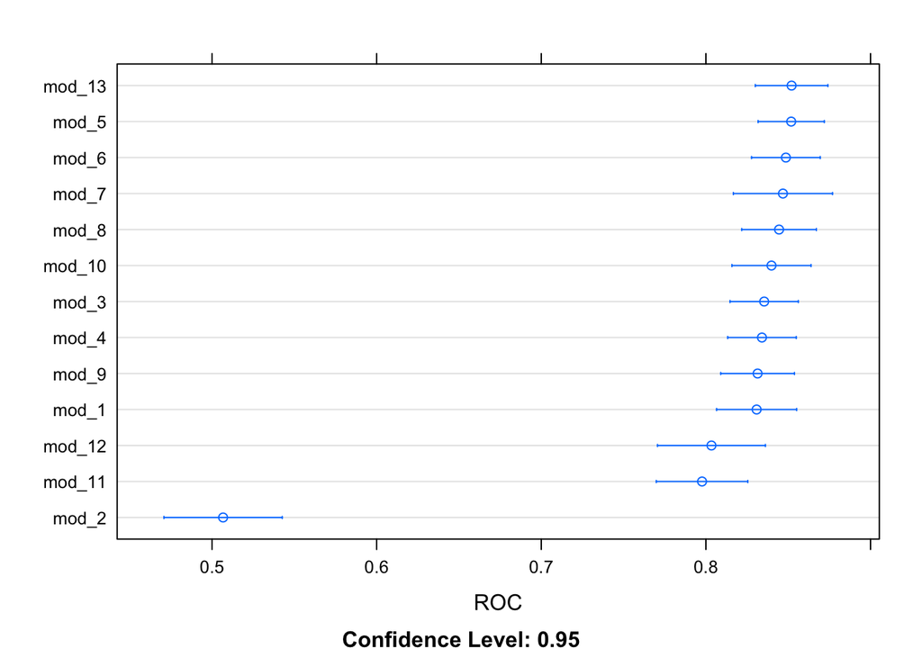

```r
dotplot(results,metric="ROC")
```

```r
library(caTools)
result_1<-predict(c_fit_glm_all_inputs,df_all_test,type='prob')
result_2<-predict(c_fit_glm_all_pairwise,df_all_test,type='prob')
```

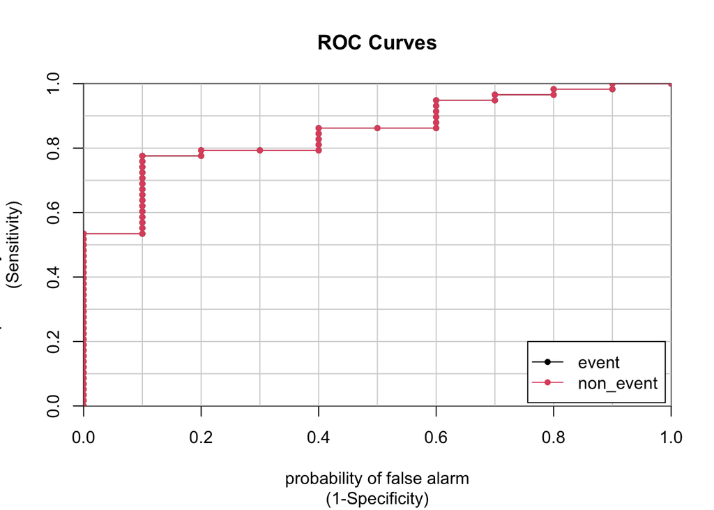

```r
result_3<-predict(c_fit_glm_8,df_all_test,type='prob')
result_4<-predict(c_fit_glm_2,df_all_test,type='prob')
result_5<-predict(c_fit_glmnet_pairwise_tune,df_all_test,type='prob')
result_6<-predict(c_fit_glmnet_3_tune,df_all_test,type='prob')
result_7<-predict(c_fit_glmnet_2_tune,df_all_test,type='prob')
result_8<-predict(c_fit_nnet_additive_tune,df_all_test,type='prob')
result_9<-predict(c_fit_rf_additive_tune,df_all_test,type='prob')
result_10<-predict(c_fit_xgb_additive_tune,df_all_test,type='prob')
result_11<-predict(c_fit_svm_additive_tune,df_all_test,type='prob')
result_12<-predict(c_fit_adaboost_additive_tune,df_all_test,type='prob')
result_13<-predict(c_pca_nnet_additive_tune,df_all_test,type='prob')
result_1<-colAUC(result_1,df_all_test$outcome,plotROC = TRUE)
```

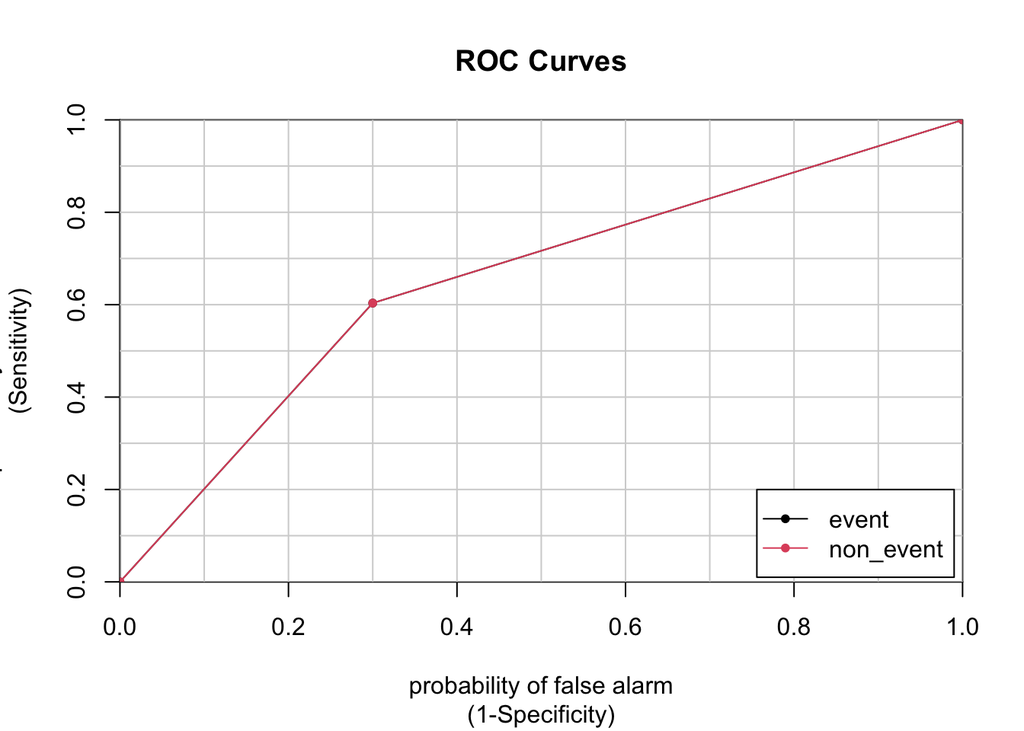

```r
result_2<-colAUC(result_2,df_all_test$outcome,plotROC = TRUE)
```

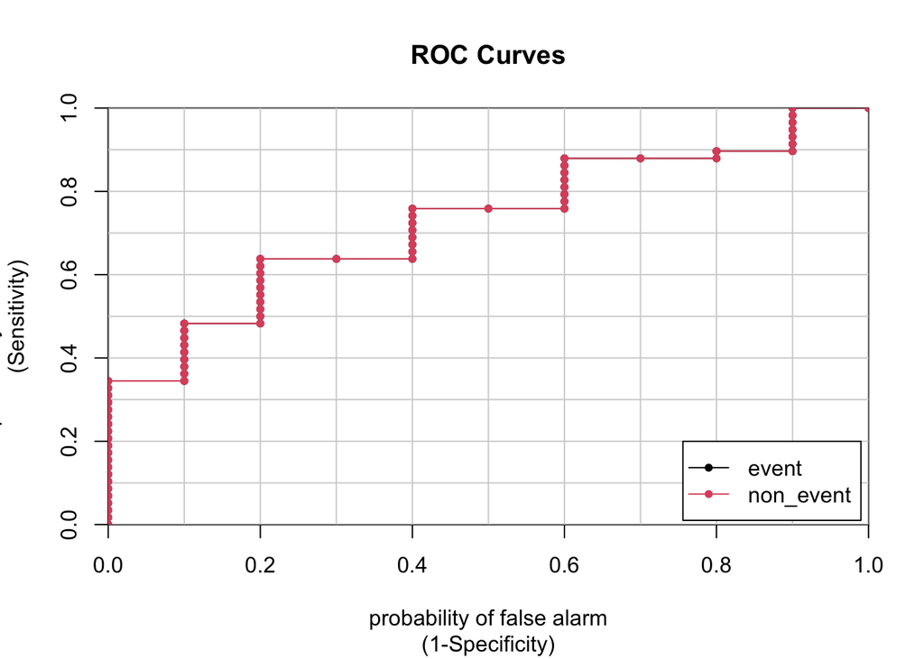

```r
result_3<-colAUC(result_3,df_all_test$outcome,plotROC = TRUE)
```

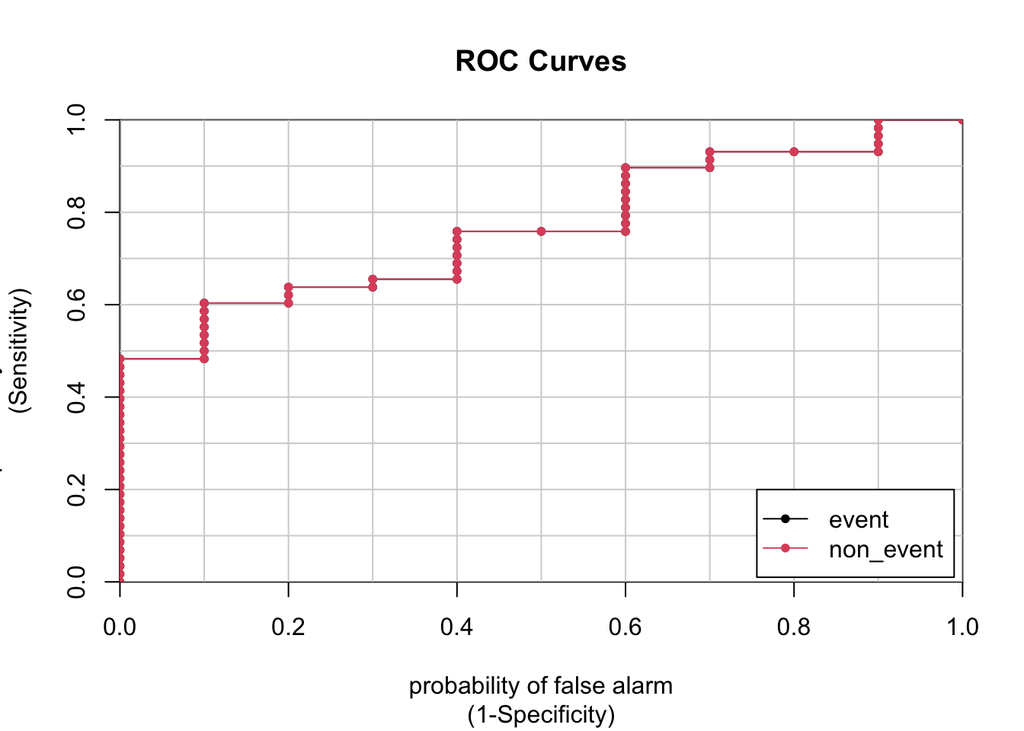

```r
result_4<-colAUC(result_4,df_all_test$outcome,plotROC = TRUE)
```

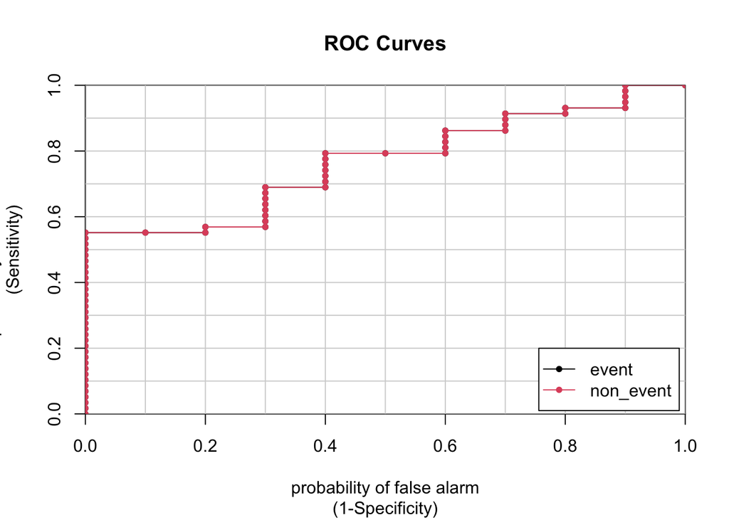

```r
result_5<-colAUC(result_5,df_all_test$outcome,plotROC = TRUE)
```

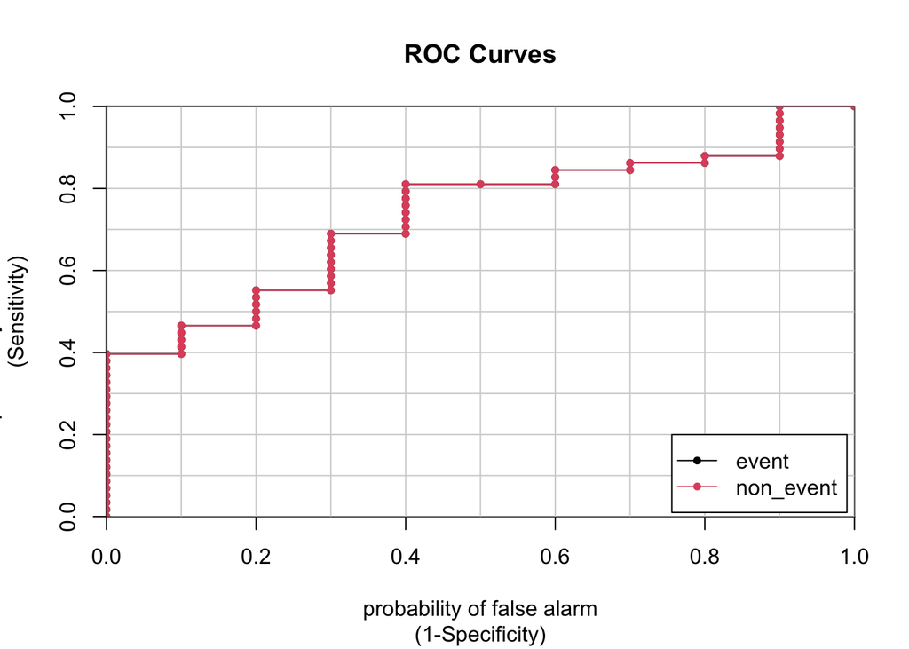

```r
result_6<-colAUC(result_6,df_all_test$outcome,plotROC = TRUE)
```

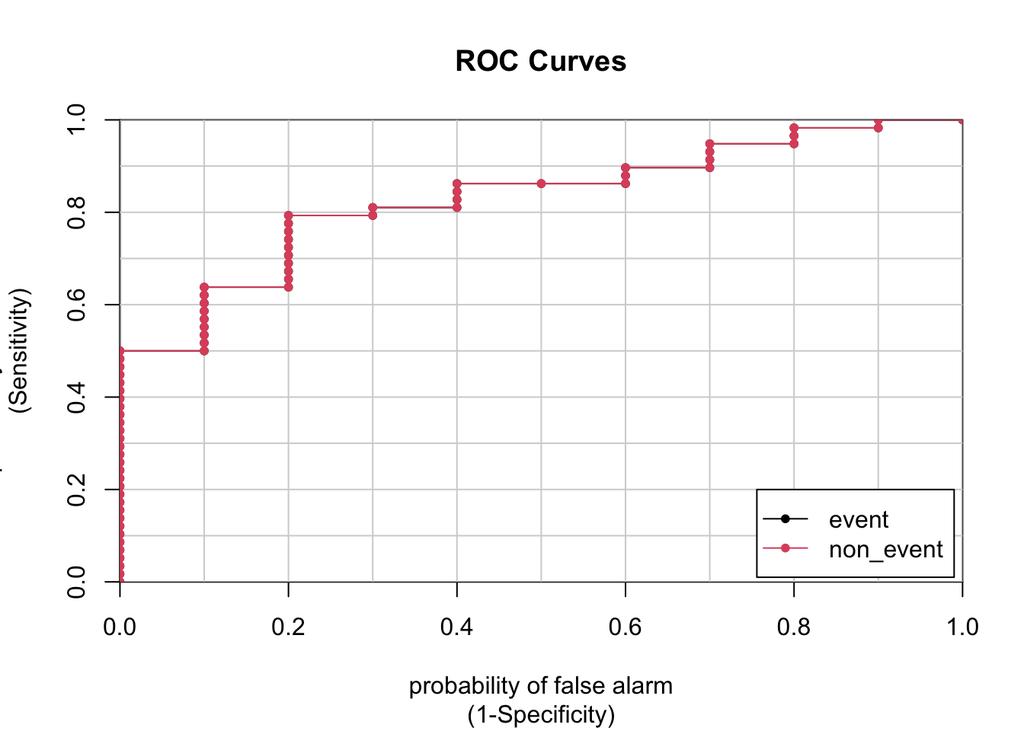

```r
result_7<-colAUC(result_7,df_all_test$outcome,plotROC = TRUE)
```

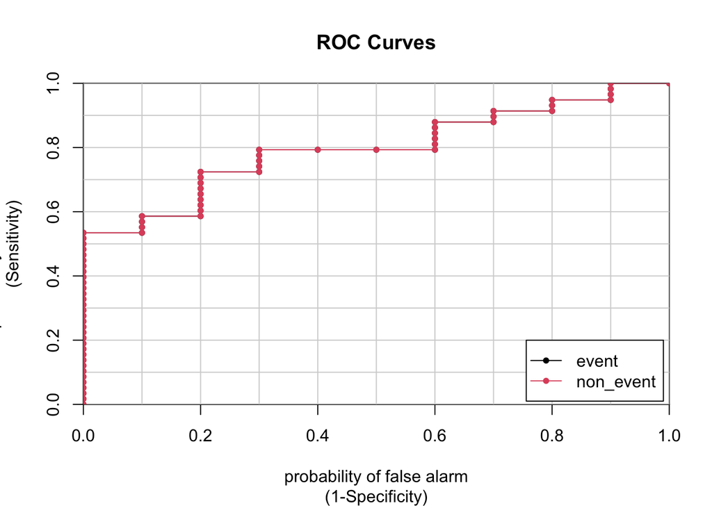

```r
result_8<-colAUC(result_8,df_all_test$outcome,plotROC = TRUE)
```

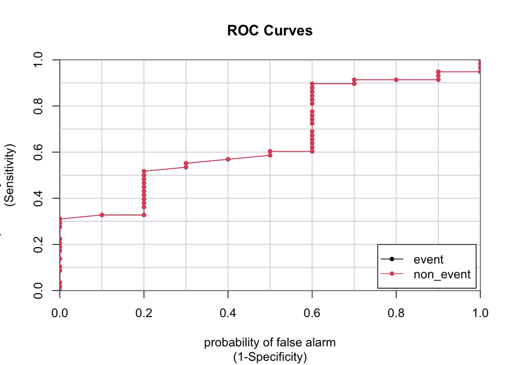

```r
result_9<-colAUC(result_9,df_all_test$outcome,plotROC = TRUE)
```

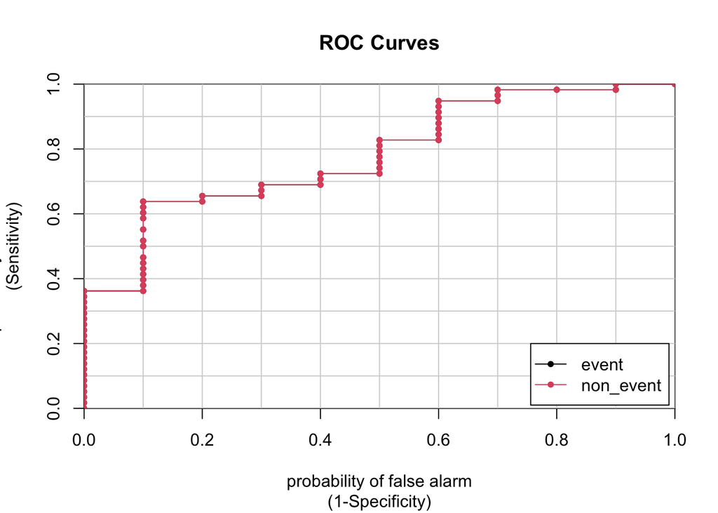

```r
result_10<-colAUC(result_10,df_all_test$outcome,plotROC = TRUE)
```

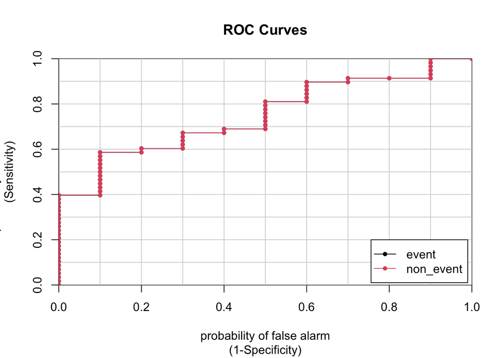

```r
result_11<-colAUC(result_11,df_all_test$outcome,plotROC = TRUE)
```

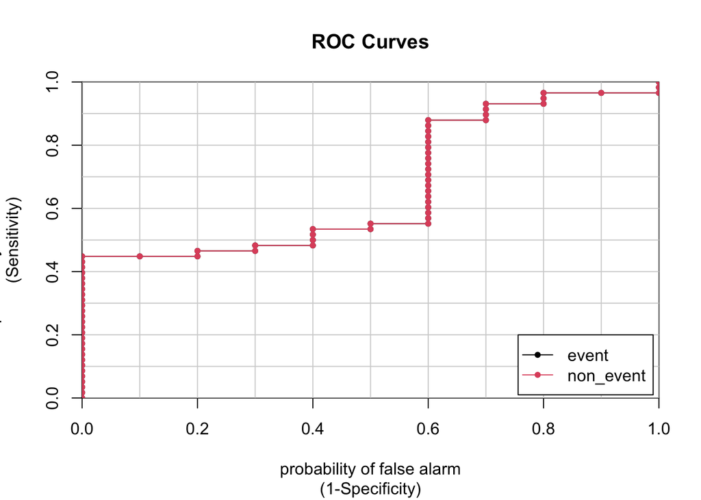

```r
result_12<-colAUC(result_12,df_all_test$outcome,plotROC = TRUE)
```